# Sentiment Analysis

There were a couple of contradictory [political events](http://www.france24.com/en/20170410-hungary-president-signs-law-threatening-soros-university) in Hungary lately and the below code tries to capture the reaction of the public by applying sentiment analysis on tweets from Twitter using 2 search words:

1. ‘Viktor Orbán’ - the current prime minister of Hungary
2. #istandwithCEU - the most used supporting hashtag of the Central European University

The tweets used in this project are from 1st until 14th April 2017.

###### *NOTE: The project doesn’t want to take a stand on or against any political sides, it only shows an example of how to use R as a data science tool for sentiment analysis. Therefore the results will not be discussed.*

I should give a huge credit to the authors of the following 2 blog articles, because the large part of the code used in this project was borrowed from them:

- [How to Use R to Scrape Tweets: Super Tuesday 2016](https://www.r-bloggers.com/how-to-use-r-to-scrape-tweets-super-tuesday-2016/) by Kris Eberwein
- [Joy to the World, and also Anticipation, Disgust, Surprise…](http://juliasilge.com/blog/Joy-to-the-World/) by Julia Silge

Okay, now let’s get started!

Reading the 2 csv files, that has been scraped from Twitter using the [twitteR](https://cran.r-project.org/web/packages/twitteR/index.html) package.

```r
t_orban <- read.csv('/Users/mac/Desktop/Egyetem/Data\ Science/Twitter/feed_orban.csv')
t_ceu <- read.csv('/Users/mac/Desktop/Egyetem/Data\ Science/Twitter/feed_ceu.csv')
```

Reading in the dictionary of positive and negative words, which is a list of 6800 positive and negative words compiled by Bing Liu and Minqing Hu of the University of Illinois at Chicago. You can download it [here](http://www.cs.uic.edu/~liub/FBS/opinion-lexicon-English.rar).

```r
good_text = scan('/Users/mac/Desktop/Egyetem/Data\ Science/Twitter/positive-words.txt',
           what='character', comment.char=';')
bad_text = scan('/Users/mac/Desktop/Egyetem/Data\ Science/Twitter/negative-words.txt',
           what='character', comment.char=';')
```

The next thing is to load a huge function, which will score the tweets, by searching for the positive and negative word instances in the text.

```r
score.sentiment = function(sentences, good_text, bad_text, .progress='none')
{
        library(plyr)
        library(stringr)
        # we got a vector of sentences. plyr will handle a list
        # or a vector as an "l" for us
        # we want a simple array of scores back, so we use
        # "l" + "a" + "ply" = "laply":
        scores = laply(sentences, function(sentence, good_text, bad_text) {

                # clean up sentences with R's regex-driven global substitute, gsub():
                sentence = gsub('[[:punct:]]', '', sentence)
                sentence = gsub('[[:cntrl:]]', '', sentence)
                sentence = gsub('\\d+', '', sentence)
                #to remove emojis
                sentence <- iconv(sentence, 'UTF-8', 'ASCII')
                sentence = tolower(sentence)
                # split into words. str_split is in the stringr package
                word.list = str_split(sentence, '\\s+')
                # sometimes a list() is one level of hierarchy too much
                words = unlist(word.list)

                # compare our words to the dictionaries of positive & negative terms
                pos.matches = match(words, good_text)
                neg.matches = match(words, bad_text)

                # match() returns the position of the matched term or NA
                # we just want a TRUE/FALSE:
                pos.matches = !is.na(pos.matches)
                neg.matches = !is.na(neg.matches)

                # and conveniently enough, TRUE/FALSE will be treated as 1/0 by sum():
                score = sum(pos.matches) - sum(neg.matches)

                return(score)
        }, good_text, bad_text, .progress=.progress )

        scores.df = data.frame(score=scores, text=sentences)
        return(scores.df)
}
```

The next step is to apply the previously defined function on the 2 loaded data frame, using the list of good and bad words from the sentiment dictionary. It will add the calculated sentiment scores to another column.

```r
sent_orban <- score.sentiment(t_orban$tweets, good_text, bad_text, .progress='none')
sent_orban <- cbind(sent_orban, date=as.factor(t_orban$date))
sent_ceu <- score.sentiment(t_ceu$tweets, good_text, bad_text, .progress='none')
sent_ceu <- cbind(sent_ceu, date=as.factor(t_ceu$date))
```

Loading a couple of libraries that will be required:

```r
library(ggplot2)
library(ggthemes)
library(tidyr)
library(dplyr)
library(stringr)
```

The upcoming barchart will be filled up with 3 color gradient, using the shades of green, yellow and red. Here is how the palette is created:

```r
colpal <- colorRampPalette(c("green3", "lemonchiffon2", "firebrick"))
```

I used a [cheatsheet](http://www.stat.columbia.edu/~tzheng/files/Rcolor.pdf) provided by Thian Zheng (associate professor at Columbia University) to grab my chosen colors. It’s a very handy tool: you can quickly select your favourite colors and copy-paste their R names into your script.

The following code will count the total number of tweets per day:

```r
sum_count_orban <-
        sent_orban %>%
        group_by(date) %>%
        count(date, date)
```

### Sentiment scores for the search term ‘Viktor Orbán’

Let’s draw the first plot about the sentiment scores of the first search term.

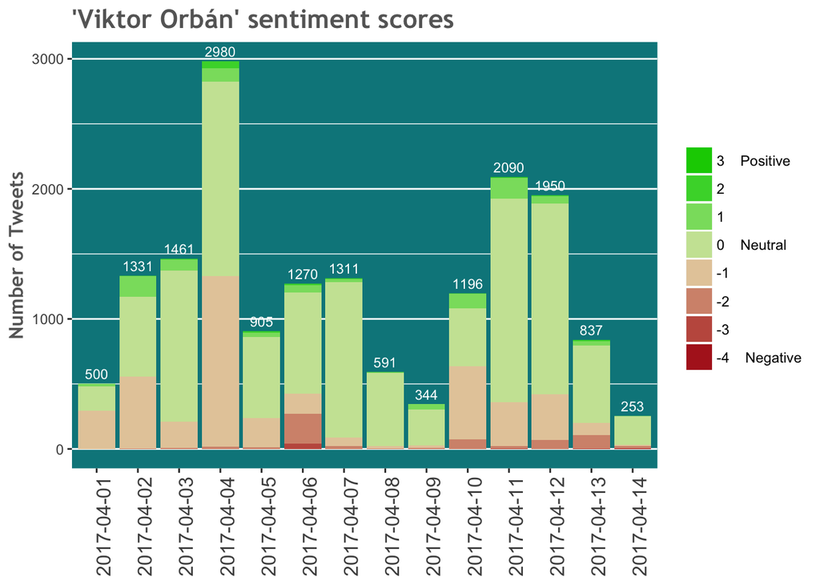

```r
p_o1 <- ggplot(data = sent_orban, aes(x = date, y = 1)) +
        geom_bar(stat = "identity",
                 aes(fill = factor(score, levels=rev(levels(as.factor(score)))))) +
        geom_text(data = sum_count_orban,
                  aes(y = n, label = n), size = 3,
                  vjust = -0.5, color = 'white') +
        scale_fill_manual(labels = c("3    Positive", "2", "1", "0    Neutral", "-1", "-2", "-3", "-4    Negative"), values = colpal(8)) +
        theme(panel.grid.major.x = element_blank(), panel.background = element_rect(fill = 'turquoise4')) +
        ggtitle("'Viktor Orbán' sentiment scores") +
        labs(y="Number of Tweets") +
        theme(legend.title=element_blank(), axis.title.x = element_blank()) +
        theme(plot.title = element_text(family = "Trebuchet MS", color="#666666", face="bold", size=16, hjust=0)) +
        theme(axis.text.x = element_text(size = 12, angle = 90, hjust = 1),
              axis.title = element_text(family = "Trebuchet MS", color="#666666", face="bold", size=12))
p_o1
```

Calculating the overall sentiment scores by grouping the positive, neutral and negative scores.

```r
stat <- mutate(sent_orban, tweet=ifelse(sent_orban$score > 0, 'positive', ifelse(sent_orban$score < 0, 'negative', 'neutral')))
by.tweet <- group_by(stat, tweet, date)
by.tweet <- summarise(by.tweet, number=n())
```

Plotting the overall sentiment scores:

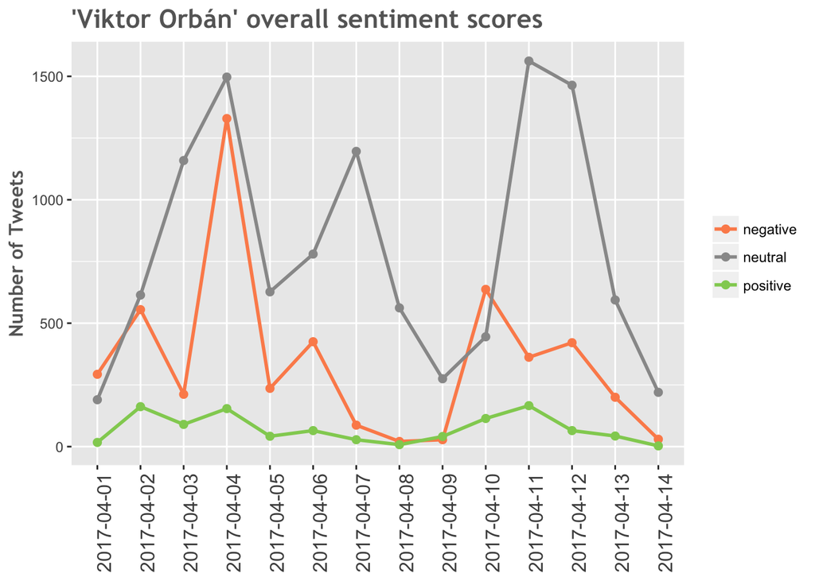

```r
p_o2 <- ggplot(by.tweet, aes(date, number)) + geom_line(aes(group=tweet, color=tweet), size=1) +
                geom_point(aes(group=tweet, color=tweet), size=2) +
                scale_color_manual(values=c("#fc8d59", "#999999", "#91cf60")) +
        ggtitle("'Viktor Orbán' overall sentiment scores") +
        labs(y="Number of Tweets") +
        theme(legend.title=element_blank(), axis.title.x = element_blank()) +
        theme(plot.title = element_text(family = "Trebuchet MS", color="#666666", face="bold", size=16, hjust=0)) +
        theme(axis.text.x = element_text(size = 12, angle = 90, hjust = 1),
              axis.title = element_text(family = "Trebuchet MS", color="#666666", face="bold", size=12))
p_o2
```

### Next stop is emotions!

Now we are trying to dig deeper and unfold the positive and negative feelings by differentiating the various emotions from each other. To make this happen, I applied an algorithm from the syuzhet package, which is based on the [NRC Word-Emotion Association Lexicon](http://saifmohammad.com/WebPages/NRC-Emotion-Lexicon.htm), done by Saif Mohammad and Peter Turney. It uses a dictionary, where each word has score, that is associated with 8 different emotions.

Loading the neccesary libraries:

```r
library(syuzhet)
library(lubridate)
library(scales)
library(reshape2)
```

First we have to remove the graphical characters in order to run the NRC algorithm on the tweets:

```r
usableText <- str_replace_all(sent_orban$text,"[^[:graph:]]", " ")
mySentiment <- get_nrc_sentiment(usableText)
tweets <- cbind(text=sent_orban$text, date=sent_orban$date, mySentiment)
```

After extracting the 8 emotion scores, we can aggregate the numbers for the visualization:

```r
sentimentTotals <- data.frame(colSums(tweets[,c(3:11)]))
names(sentimentTotals) <- "count"
sentimentTotals <- cbind("sentiment" = rownames(sentimentTotals), sentimentTotals)
rownames(sentimentTotals) <- NULL
```

Let’s look into the data frame that we got:

```r
sentimentTotals
```

```
##      sentiment count
## 1        anger  8175
## 2 anticipation  5178
## 3      disgust  3416
## 4         fear  9328
## 5          joy  1481
## 6      sadness  6146
## 7     surprise  3520
## 8        trust  5792
## 9     negative 12830
```

Now we are ready to plot the aggregated scores by emotions and check their distribution:

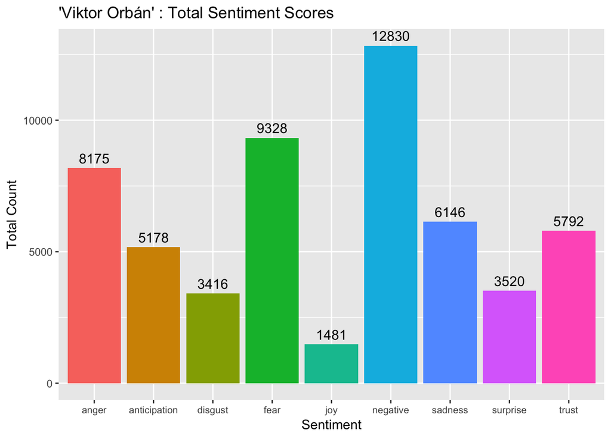

```r
p_o3 <- ggplot(data = sentimentTotals, aes(x = sentiment, y = count)) +
        geom_bar(aes(fill = sentiment), stat = "identity") +
        geom_text(data = sentimentTotals,
                  aes(y = count, label = count), size = 4,
                  vjust = -0.5, color = 'black') +
        theme(legend.position = "none") +
        theme(axis.text.x = element_text(size = 8)) +
        xlab("Sentiment") + ylab("Total Count") + ggtitle("'Viktor Orbán' : Total Sentiment Scores")
p_o3
```

For the last plot, we summarize the average score of the emotions by day. This will give a nice overview of the different feelings changing over time.

To prepare the data for visualization, the mean of the sentiments should be grouped by date:

```r
tweets$day <- date(tweets$date)
dailysentiment <- tweets %>% group_by(date) %>%
        summarise(anger = mean(anger),
                  anticipation = mean(anticipation),
                  disgust = mean(disgust),
                  fear = mean(fear),
                  joy = mean(joy),
                  sadness = mean(sadness),
                  surprise = mean(surprise),
                  trust = mean(trust)) %>% melt
names(dailysentiment) <- c("date", "sentiment", "meanvalue")
```

The average sentiment scores are ready to be plotted now:

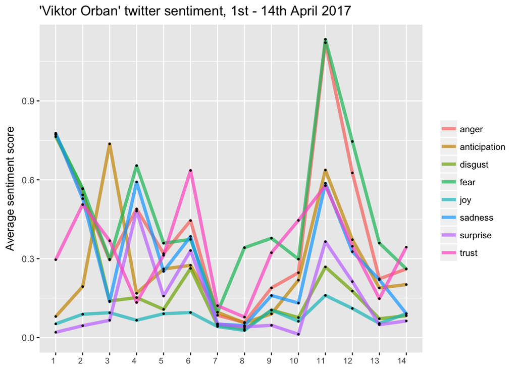

```r
p_o4 <- ggplot(data = dailysentiment, aes(x = as.factor(day(date)), y = meanvalue, group = sentiment)) +
        geom_line(size = 1.5, alpha = 0.7, aes(color = sentiment)) +
        geom_point(size = 0.5) +
        ylim(0, NA) +
        theme(legend.title=element_blank(), axis.title.x = element_blank()) +
        ylab("Average sentiment score") +
        ggtitle("'Viktor Orban' twitter sentiment, 1st - 14th April 2017") +
        theme(axis.text.x = element_text(size = 8, hjust = 1))
p_o4
```

### Compare the results of the 2 search terms

We simply run the same code for the second search term and plot the results side by side with the first term:

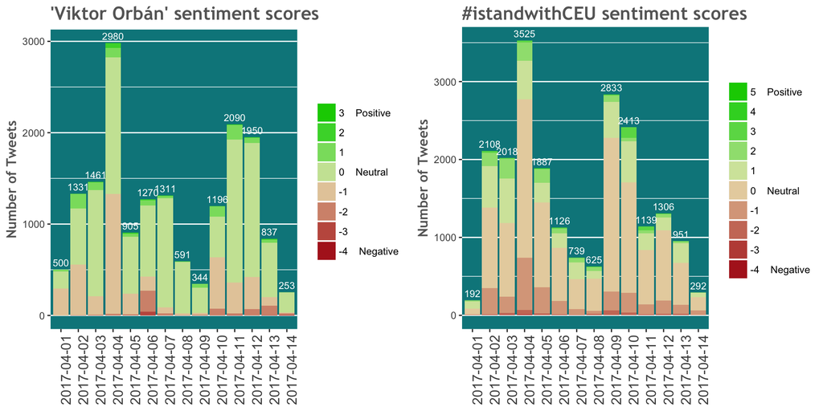

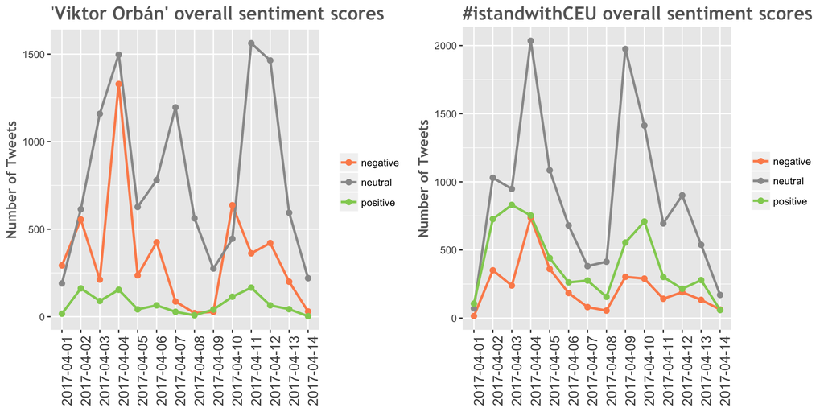

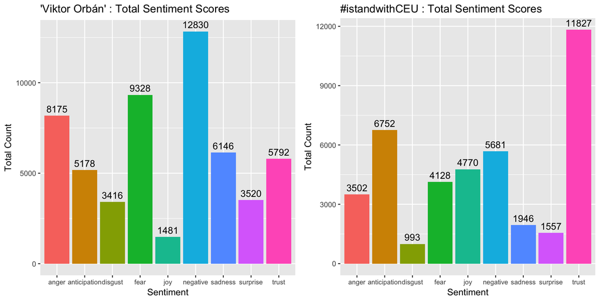

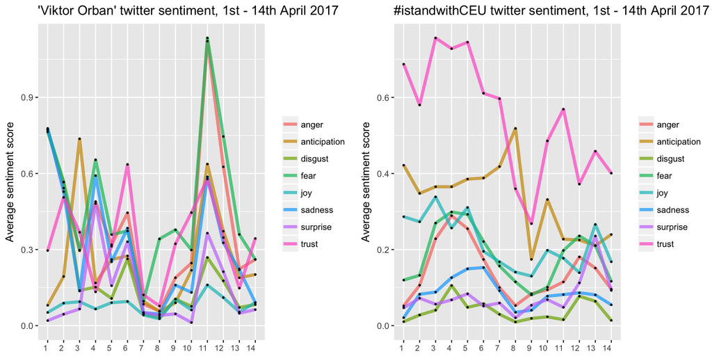